# TM4SF1 Fig. 3 figure development

Publication-panel drafts from the corrected v2.2.1 case-study outputs

Published

19 Aug 2026

This report develops candidate panels for a provisional full-width manuscript Fig. 3. It is a plotting layer over the corrected v2.2.1 TM4SF1 report: no posterior prediction, marginalisation, threshold construction, admissibility rule, donor-support rule, candidate definition, or tumour reconstruction is rerun or changed. Panels are deliberately shown separately rather than assembled.

**Important**

The current epithelial and endothelial fits do not pass the registered model- readiness gate. Overlap is a prioritisation signal, not evidence of toxicity. Prediction visibility and empirical support remain separate throughout.

# Proposed Fig. 3 layout

The planning canvas is 183 mm × approximately 203 mm: Row 1, 48 mm; Row 2, 92 mm; Row 3, 55 mm; with two approximately 4 mm gutters. HTML chunks are enlarged for on-screen review; intended print sizes remain in the Size/change notes.

## Row 1 — establish the case and compartments

### Panel A — released study result

#### Draft A1 — released cell-level source with patient summaries

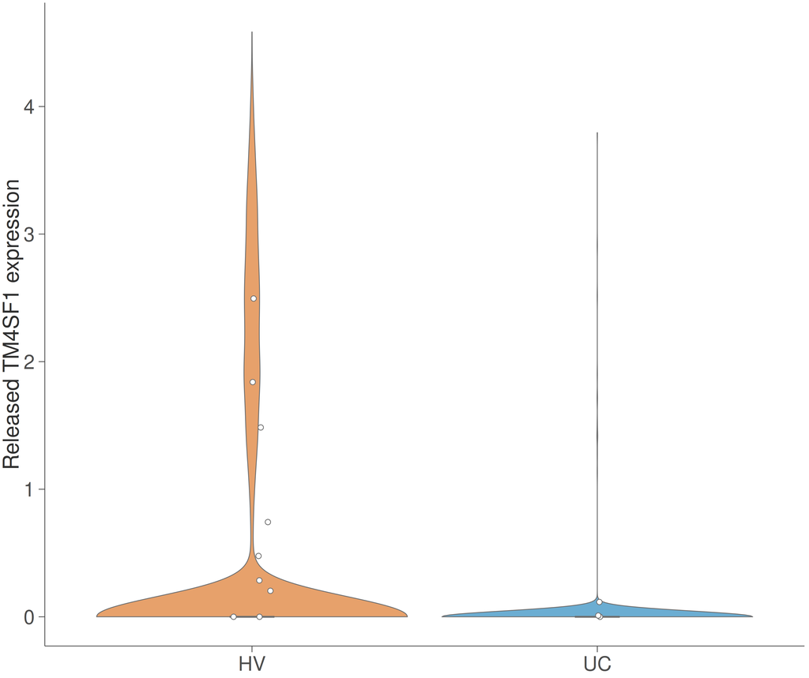

Released Figure 5B TM4SF1 values. Violins show released cell-level values; filled points show patient means.

```r
panel_a_released <- ggplot(
  paper_cells,
  aes(histology_group, source_expression, fill = histology_group)
) +
  geom_violin(
    scale = "width", trim = TRUE, colour = fig3_col[["neutral"]],
    linewidth = 0.22, alpha = 0.58
  ) +
  geom_boxplot(
    width = 0.13, outlier.shape = NA, fill = "white",
    colour = fig3_col[["neutral"]], linewidth = 0.24
  ) +
  geom_point(
    data = paper_cell_patient,
    aes(y = mean_source_expression),
    position = position_jitter(width = 0.055, height = 0),
    shape = 21, fill = "white", colour = fig3_col[["neutral"]],
    size = 1.2, stroke = 0.3
  ) +
  scale_fill_manual(values = fig3_col[c("HV", "UC")]) +
  labs(x = NULL, y = "Released TM4SF1 expression") +
  guides(fill = "none") +
  theme_fig3_compact()

panel_a_released
```

- **Message:** the released study source shows TM4SF1 enrichment in HV tumour epithelial cells.
- **Source:** released Figure 5B values and patient summaries; the released Figure 5A result ranks TM4SF1 first among HV-enriched genes (log2FC 2.36).
- **Size/change:** 57 × 48 mm; replaces a large volcano with a compact source-faithful distribution and patient-level overlay.
- **Weakness/next:** cell values are descriptive and patients are the independent units; use this as Panel A, with the reconstruction limitation in the caption.

#### Draft A2 — public-DGE patient reconstruction

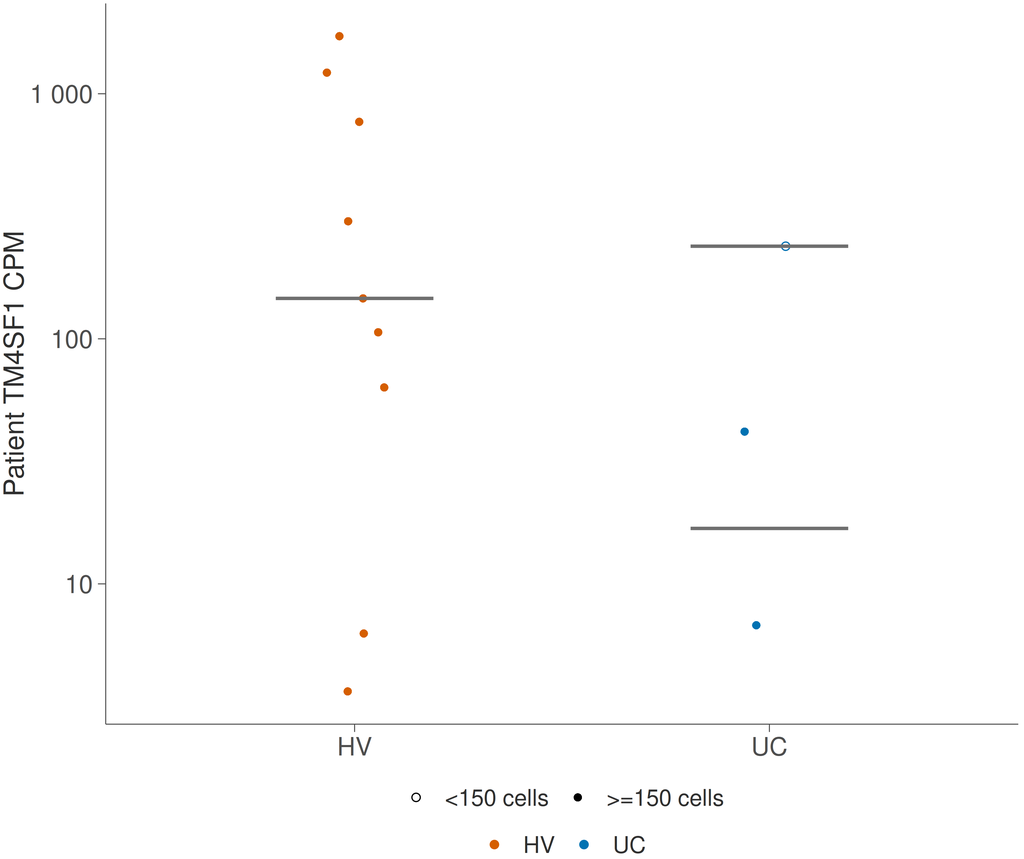

Patient-level TM4SF1 CPM reconstructed from the public DGE matrices. Open points fail the reconstructed 150-cell rule.

```r
panel_a_reconstruction_data <- tm4_patient |>
  filter(
    sample_type == "tumour",
    broad_cell_type == "epithelial",
    paper_id %in% c(sprintf("VAR%02d", 1:9), sprintf("UC%02d", 1:3))
  ) |>
  mutate(
    reconstruction_support = if_else(
      reconstructed_n150_threshold_met, ">=150 cells", "<150 cells"
    )
  )

panel_a_reconstruction <- ggplot(
  panel_a_reconstruction_data,
  aes(histology_group, CPM, colour = histology_group, shape = reconstruction_support)
) +
  geom_point(
    position = position_jitter(width = 0.08, height = 0),
    size = 1.45, stroke = 0.38
  ) +
  stat_summary(
    fun = median, geom = "crossbar", width = 0.38,
    colour = fig3_col[["neutral"]], linewidth = 0.28
  ) +
  scale_colour_manual(values = fig3_col[c("HV", "UC")]) +
  scale_shape_manual(values = c(">=150 cells" = 16, "<150 cells" = 1)) +
  scale_y_continuous(
    trans = scales::transform_pseudo_log(sigma = 0.1, base = 10),
    breaks = c(0, 0.1, 1, 10, 100, 1000),
    labels = label_number()
  ) +
  labs(x = NULL, y = "Patient TM4SF1 CPM", colour = NULL, shape = NULL) +
  theme_fig3_compact() +
  theme(legend.position = "bottom", legend.box = "vertical")

panel_a_reconstruction
```

- **Message:** the patient-level public reconstruction supports HV enrichment but also exposes strong tumour heterogeneity.
- **Source:** reconstructed raw-count patient pseudobulks; closest fixed-seed comparison is 9 HV versus 2 UC at the 150-cell rule.
- **Size/change:** 57 × 48 mm; retains UC01 as a visibly low-cell, open point rather than hiding it.
- **Weakness/next:** it is not an exact 9 HV + 3 UC reproduction; retain as an alternate/audit panel, not the primary Panel A.

### Panel B — tumour anchor to Normal reference

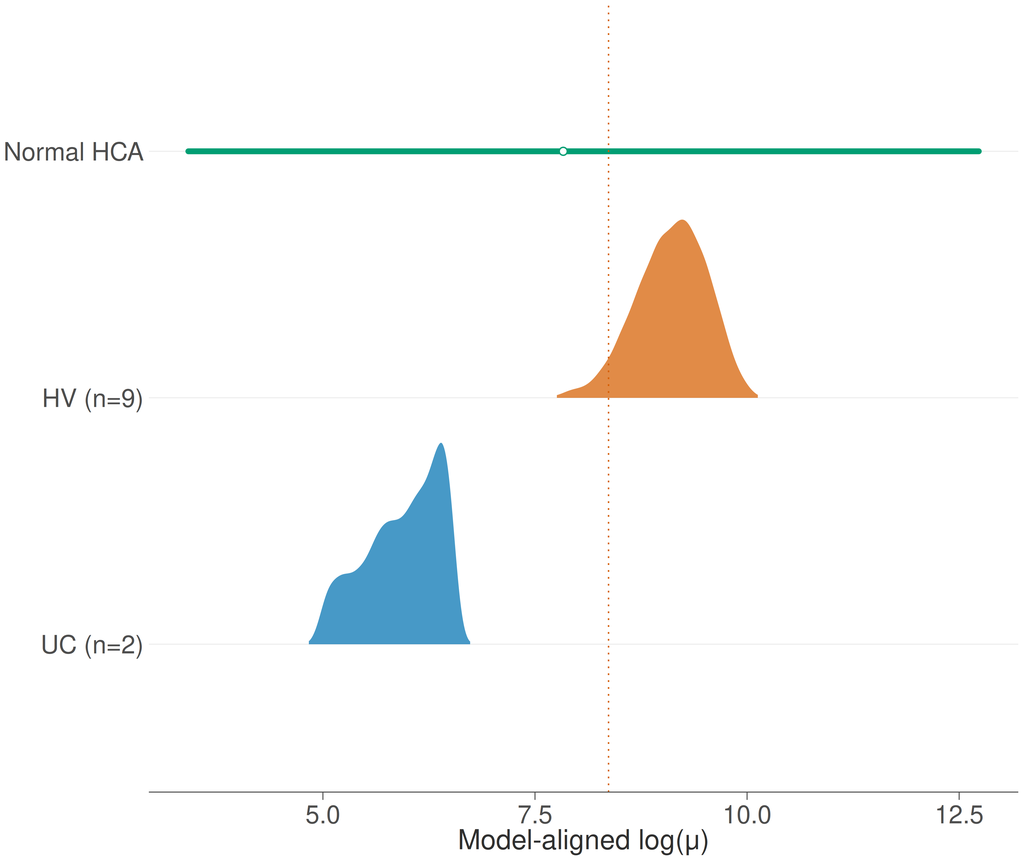

Tumour-cohort bootstrap distributions and the comprehensive epithelial posteriorHCA Normal reference on the epithelial model-aligned scale. The dashed line is the registered 5% HV anchor.

```r
panel_b_draws <- study_draws |>
  filter(
    cell_type == "epithelial",
    group %in% c(
      "HV tumour epithelial",
      "UC tumour epithelial (2 public-DGE >=150)"
    )
  ) |>
  mutate(
    display_group = recode(
      group,
      "HV tumour epithelial" = "HV (n=9)",
      "UC tumour epithelial (2 public-DGE >=150)" = "UC (n=2)"
    ),
    display_group = factor(
      display_group,
      levels = c("Normal HCA", "UC (n=2)", "HV (n=9)")
    )
  )

panel_b_hca <- profile_summary |>
  filter(cell_type == "epithelial", dimension == "comprehensive") |>
  mutate(
    display_group = factor(
      "Normal HCA",
      levels = c("Normal HCA", "UC (n=2)", "HV (n=9)")
    )
  )

panel_b <- ggplot() +
  ggridges::geom_density_ridges(
    data = panel_b_draws,
    aes(log_mu, display_group, fill = display_group),
    scale = 0.82, rel_min_height = 0.015,
    colour = "white", linewidth = 0.24, alpha = 0.72
  ) +
  geom_segment(
    data = panel_b_hca,
    aes(
      x = lower_log_mu, xend = upper_log_mu,
      y = display_group, yend = display_group
    ),
    colour = fig3_col[["Normal"]], linewidth = 1.2, lineend = "round"
  ) +
  geom_point(
    data = panel_b_hca,
    aes(median_log_mu, display_group),
    shape = 21, fill = "white", colour = fig3_col[["Normal"]],
    size = 1.35, stroke = 0.42
  ) +
  geom_vline(
    xintercept = panel_b_hca$threshold_log_mu,
    colour = fig3_col[["HV"]], linetype = 3, linewidth = 0.3
  ) +
  scale_fill_manual(values = c(
    "HV (n=9)" = fig3_col[["HV"]],
    "UC (n=2)" = fig3_col[["UC"]]
  )) +
  labs(x = "Model-aligned log(μ)", y = NULL) +
  guides(fill = "none") +
  theme_fig3_compact() +
  theme(
    axis.line.y = element_blank(), axis.ticks.y = element_blank(),
    panel.grid.major.y = element_line(colour = "#ECECEC", linewidth = 0.2)
  )

panel_b
```

- **Message:** posteriorHCA evaluates Normal expression on an HV-derived tumour scale; it is not another tumour DEG test.
- **Source:** exact patient Bayesian-bootstrap study draws plus the exact comprehensive epithelial posterior median and 95% interval.
- **Size/change:** 57 × 48 mm; aligns tumour distributions, the HV anchor, and Normal reference in one compact bridge.
- **Weakness/next:** the panel is epithelial-model specific; state that cell-type model scales are separately aligned and not interchangeable.

### Panel C — broad Normal compartments

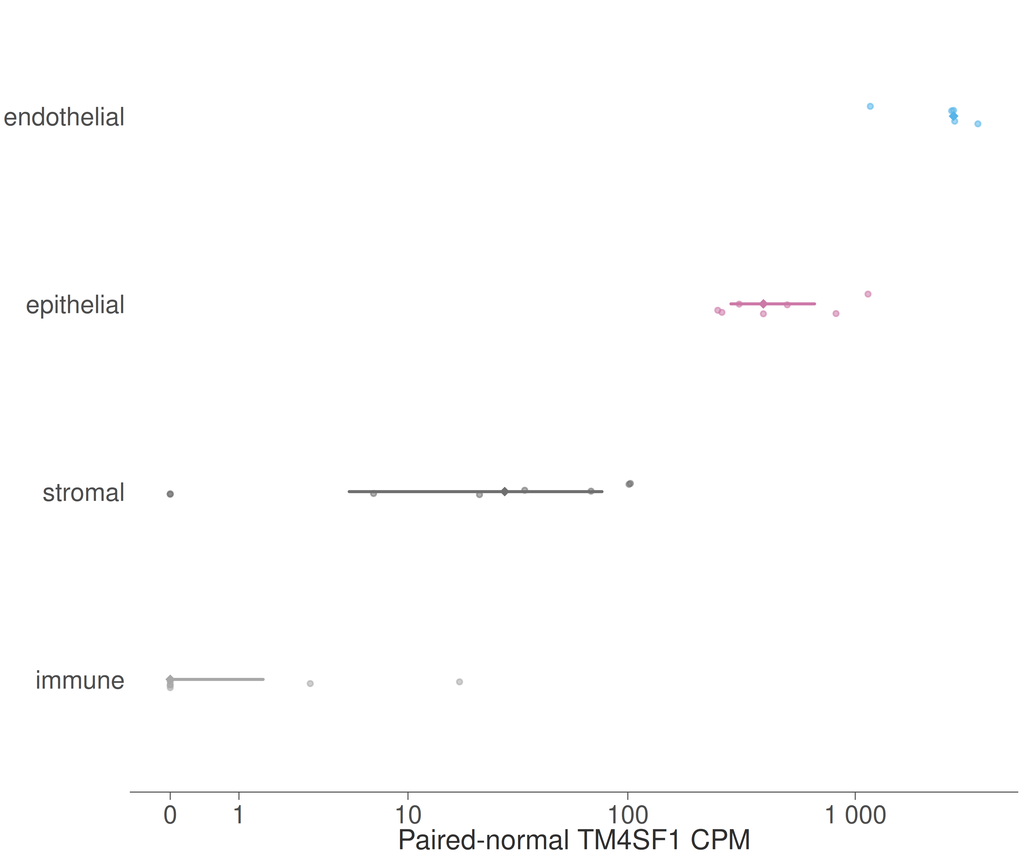

Patient-level TM4SF1 CPM in paired/adjacent normal bladder broad populations. Large diamonds are medians and bars are interquartile ranges.

```r
panel_c_points <- tm4_patient |>
  filter(
    sample_type == "paired_normal",
    broad_cell_type %in% c("epithelial", "endothelial", "stromal", "immune")
  )

panel_c_summary <- panel_c_points |>
  group_by(broad_cell_type) |>
  summarise(
    median_CPM = median(CPM),
    lower_CPM = quantile(CPM, 0.25),
    upper_CPM = quantile(CPM, 0.75),
    .groups = "drop"
  ) |>
  arrange(median_CPM) |>
  mutate(broad_cell_type = factor(broad_cell_type, levels = broad_cell_type))

panel_c_points <- panel_c_points |>
  mutate(
    broad_cell_type = factor(
      broad_cell_type, levels = levels(panel_c_summary$broad_cell_type)
    )
  )

population_col <- c(
  epithelial = fig3_col[["epithelial"]],
  endothelial = fig3_col[["endothelial"]],
  stromal = fig3_col[["neutral"]],
  immune = "#A8A8A8"
)

panel_c <- ggplot(panel_c_points, aes(CPM, broad_cell_type, colour = broad_cell_type)) +
  geom_point(
    position = position_jitter(width = 0, height = 0.055),
    size = 0.8, alpha = 0.55
  ) +
  geom_segment(
    data = panel_c_summary,
    aes(x = lower_CPM, xend = upper_CPM, yend = broad_cell_type),
    linewidth = 0.62, lineend = "round"
  ) +
  geom_point(
    data = panel_c_summary, aes(median_CPM),
    shape = 18, size = 1.65
  ) +
  scale_colour_manual(values = population_col) +
  scale_x_continuous(
    trans = scales::transform_log1p(),
    breaks = c(0, 1, 10, 100, 1000), labels = label_number()
  ) +
  labs(x = "Paired-normal TM4SF1 CPM", y = NULL) +
  guides(colour = "none") +
  theme_fig3_compact() +
  theme(axis.line.y = element_blank(), axis.ticks.y = element_blank())

panel_c
```

- **Message:** paired/adjacent normal broad-population data motivate separate epithelial and endothelial follow-up.
- **Source:** reconstructed patient pseudobulks; points remain descriptive because these samples are adjacent/paired normal, not fully healthy tissue.
- **Size/change:** 57 × 48 mm; ranks populations by median expression and highlights the two modelled compartments without implying a broader posteriorHCA model set.
- **Weakness/next:** posteriorHCA has only epithelial and endothelial models here; keep that limitation explicit in the caption.

**Intended Row 1 message:** TM4SF1 is an HV-enriched tumour target in the released source, its patient-level tumour abundance is heterogeneous, and epithelial plus endothelial Normal compartments are the defensible focus for model-aligned screening. A1–C make that transition successfully if A1 remains the main source-faithful Panel A and A2 is retained as an audit alternative.

## Row 2 — main tissue-level posteriorHCA result

The smooth Normal slabs below are quantile-matched visual envelopes through the cached posterior median and 95% interval. The interval bar, median point, reported overlap probability (`P`), donor count (`n`), HV bootstrap density, and registered anchor are exact cached results. Filled circle = at least 10 donor keys; open circle = 1–9; cross = zero. Support changes opacity and line style only; it does not control visibility.

### Panel D — endothelial

#### Draft D1 — comprehensive tissue landscape

```r
panel_d_comprehensive <- plot_tissue_density("endothelial", ncol = 4)
panel_d_comprehensive
```

[figure not shown]

All endothelial tissue baselines, ordered by P(Normal ≥ HV anchor). Normal slabs are quantile-matched renderings; exact medians and 95% intervals appear at each facet baseline.

- **Message/source:** complete endothelial tissue landscape from the corrected profile summary and exact endothelial HV bootstrap draws.
- **Size/change:** 89 × 92 mm; replaces the report forest plot with repeated Normal-versus-HV distribution grammar and direct `P`, `n`, and support marks.
- **Weakness:** 29 facets are too dense for confident main-text reading at final size, and unsupported tissues broaden the common scale.
- **Recommendation:** retain as a Supplementary/exhaustive design reference, not the main Panel D.

#### Draft D2 — main-text prioritised

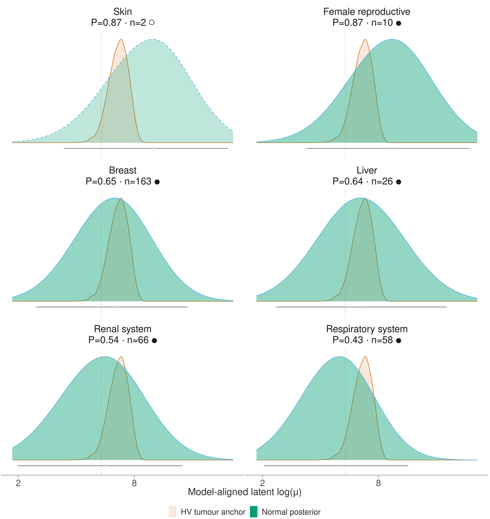

Prioritised endothelial tissue set. Female reproductive, skin, and respiratory tissues are retained for story evaluation; breast, liver, and renal provide supported comparators.

```r
endo_main_tissues <- c(
  "female reproductive system",
  "integumentary system (skin)",
  "breast",
  "liver",
  "renal system",
  "respiratory system"
)
panel_d_prioritised <- plot_tissue_density(
  "endothelial", endo_main_tissues, ncol = 2
)
panel_d_prioritised
```

- **Message/source:** the high-overlap female-reproductive estimate is supported; the similarly high skin estimate is visibly low-support; respiratory is a supported negative comparator.
- **Size/change:** 89 × 92 mm; six facets preserve density shape and annotations at final size.
- **Weakness:** skin remains 98.6% extrapolation-weighted and should not be presented as a robust signal.
- **Recommendation:** use this grammar for Panel D, but consider moving skin to Supplementary once Row 3 adopts respiratory.

### Panel E — epithelial

#### Draft E1 — comprehensive tissue landscape

```r
panel_e_comprehensive <- plot_tissue_density("epithelial", ncol = 4)
panel_e_comprehensive
```

[figure not shown]

All epithelial tissue baselines, ordered by P(Normal ≥ HV anchor). Normal slabs are quantile-matched renderings; exact medians and 95% intervals appear at each facet baseline.

- **Message/source:** complete epithelial tissue landscape from the corrected profile summary and exact epithelial HV bootstrap draws.
- **Size/change:** 89 × 92 mm; uses the same visual grammar as D without forcing a shared, biologically non-equivalent model scale.
- **Weakness:** 21 facets remain crowded and the wide uncertainty makes small ranking differences visually unimportant.
- **Recommendation:** use as the exhaustive/Supplementary version.

#### Draft E2 — main-text prioritised

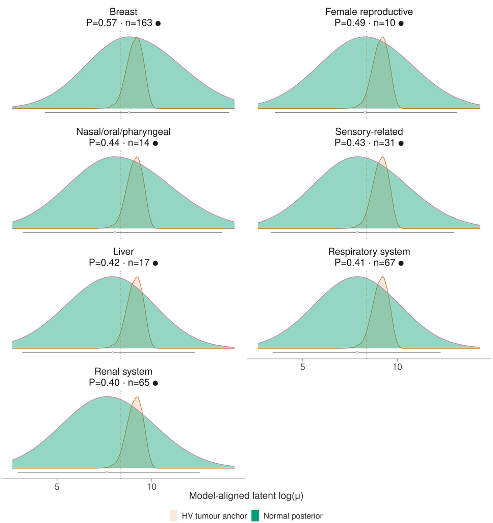

Prioritised epithelial tissue set, retaining supported high-expression tissues and respiratory/renal comparators.

```r
epi_main_tissues <- c(
  "breast",
  "female reproductive system",
  "nasal, oral, and pharyngeal regions",
  "sensory-related structures",
  "liver",
  "renal system",
  "respiratory system"
)
panel_e_prioritised <- plot_tissue_density(
  "epithelial", epi_main_tissues, ncol = 2
)
panel_e_prioritised
```

- **Message/source:** epithelial tissue estimates show weaker overlap than the endothelial lead signal, with broad uncertainty despite adequate donor counts in the selected set.
- **Size/change:** 89 × 92 mm; seven supported facets remain legible and preserve the D-panel grammar.
- **Weakness:** none pass the registered 0.80 prototype rule, and the model itself is not readiness-qualified.
- **Recommendation:** use E2; keep the comprehensive E1 landscape in Supplementary.

**Intended Row 2 message:** tissue-specific Normal relationships to the HV anchor differ sharply between endothelial and epithelial models. The overlaid density/interval style is the most interpretable at 89 × 92 mm when restricted to approximately six or seven facets. The comprehensive drafts are valuable for inclusion review but are too dense for the main text.

## Row 3 — demographic refinement of selected tissues

Row 3 focuses on the endothelial model because the female-reproductive and skin lead signals arise there. Each panel shows both proposed stories: female reproductive + respiratory (supported negative comparator) and female reproductive + skin (high-overlap but extrapolation-sensitive). Structurally impossible male estimates for female reproductive tissue are absent.

### Panel F — sex

#### Draft F1 — female reproductive + respiratory

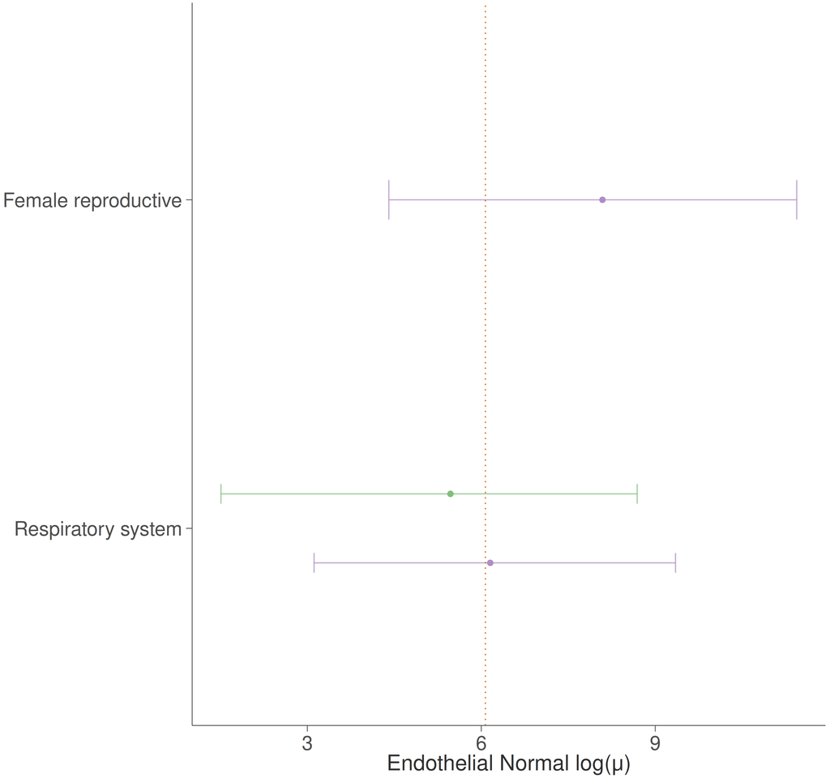

Endothelial sex marginals for the respiratory comparator. Purple is female and green is male; point shape denotes support. Female reproductive tissue has one structurally female tissue baseline rather than an invented male estimate.

```r
panel_f_respiratory <- plot_story_sex("respiratory system")
panel_f_respiratory
```

- **Message/source:** respiratory female and male marginals are directly comparable and supported; female reproductive remains a female-only tissue baseline.
- **Size/change:** 58 × 55 mm; paired point-ranges replace the report-wide sex forest plot.
- **Weakness:** intervals are broad and do not establish a robust sex effect.
- **Recommendation:** preferred Panel F draft because the comparator is adequately supported.

#### Draft F2 — female reproductive + skin

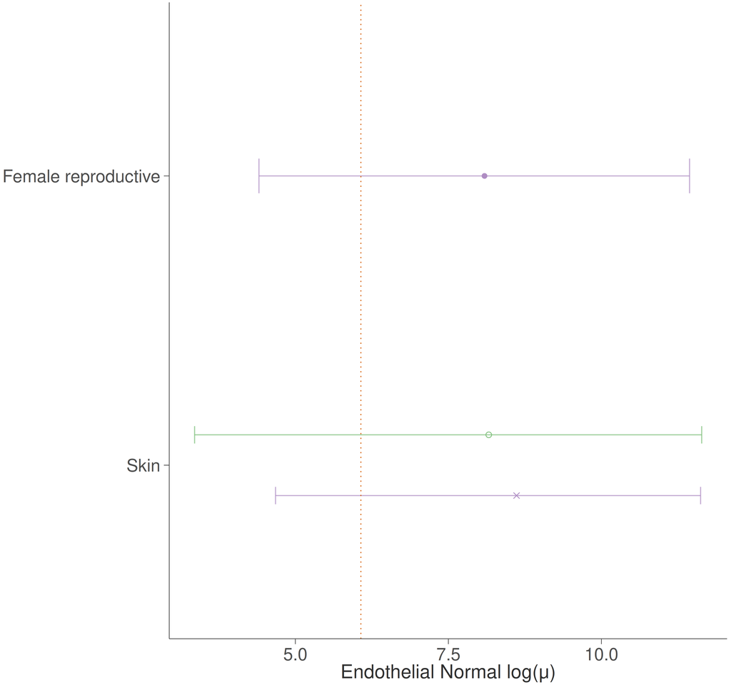

Endothelial sex marginals for skin. Purple is female and green is male; point shape denotes support. Both skin sex estimates have limited or absent direct support.

```r
panel_f_skin <- plot_story_sex("integumentary system (skin)")
panel_f_skin
```

- **Message/source:** the apparent skin sex contrast is prediction-visible but empirically weak.
- **Size/change:** 58 × 55 mm; open/cross marks keep low-support estimates visible without giving them equal visual authority.
- **Weakness:** female skin has zero donor keys and male skin has two; neither can sustain a main-text demographic claim.
- **Recommendation:** retain for development/Supplementary only.

### Panel G — age decade

#### Draft G1 — female reproductive + respiratory

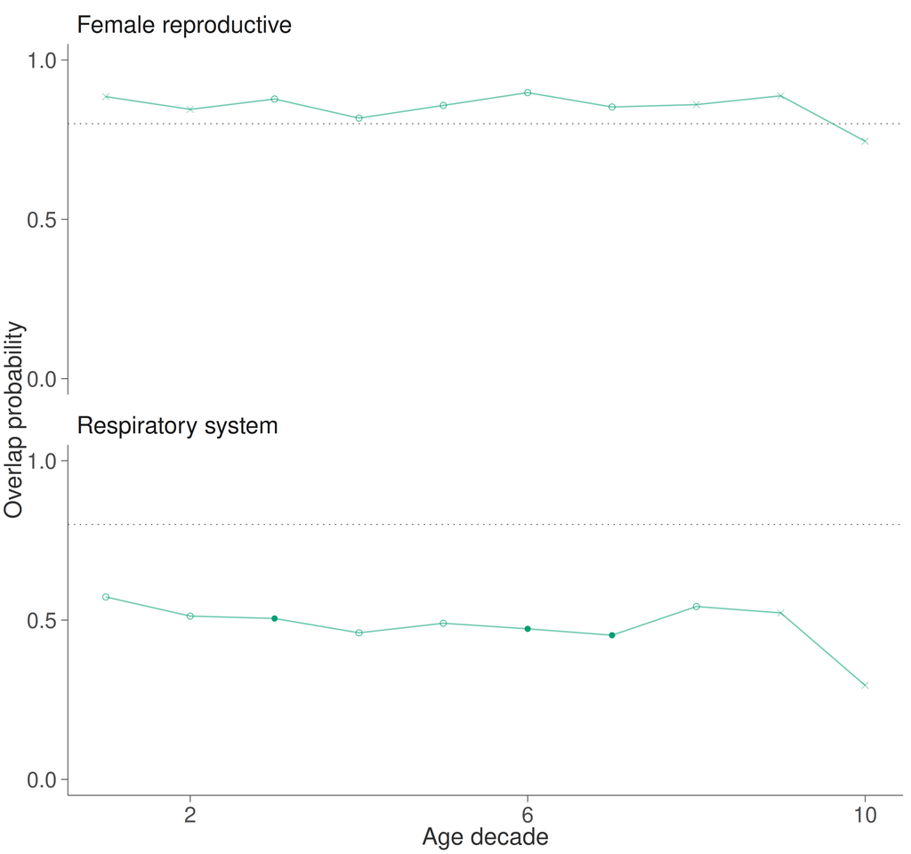

Endothelial overlap probability by age decade for female reproductive and respiratory tissues. Lines are visual guides between discrete marginal estimates.

```r
panel_g_respiratory <- plot_story_age("respiratory system")
panel_g_respiratory
```

- **Message/source:** female-reproductive overlap is consistently high but sparsely supported; respiratory remains lower with several supported decades.
- **Size/change:** 58 × 55 mm; ordered points and guide-lines replace the age heatmap.
- **Weakness:** decade-specific marginals are not a fitted continuous biological age trend.
- **Recommendation:** preferred Panel G draft, with the guide-line caveat in the caption.

#### Draft G2 — female reproductive + skin

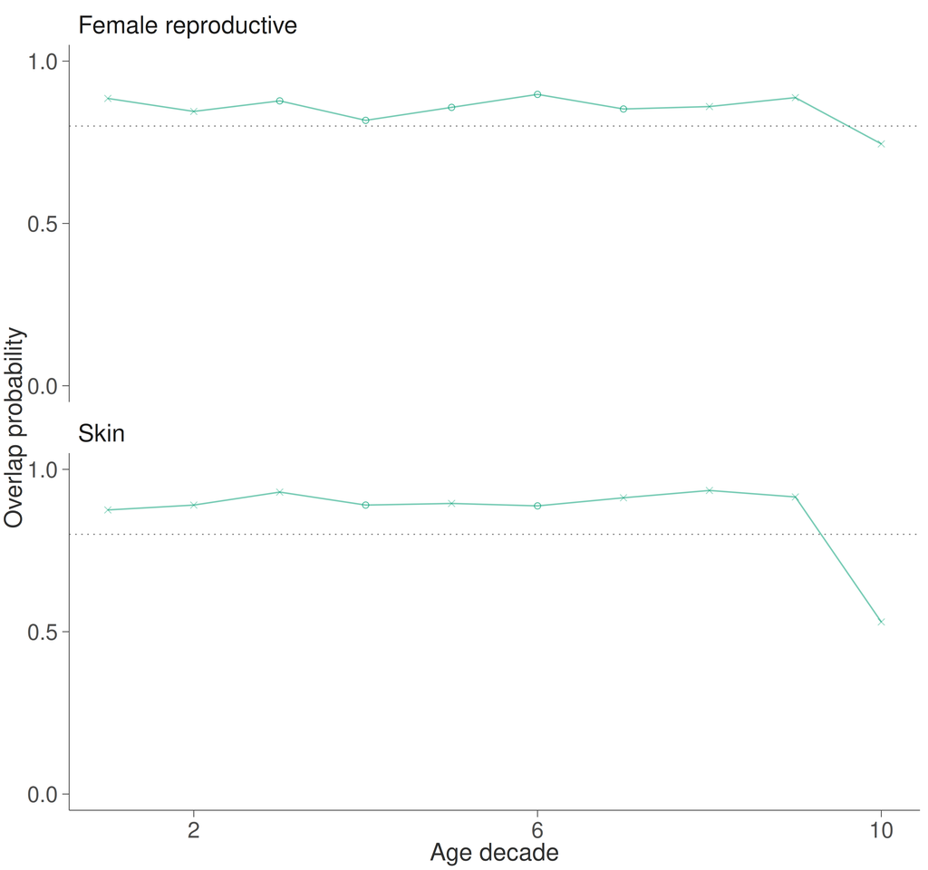

Endothelial overlap probability by age decade for female reproductive and skin tissues. Nearly all skin strata are extrapolated.

```r
panel_g_skin <- plot_story_age("integumentary system (skin)")
panel_g_skin
```

- **Message/source:** high skin overlap across decades is dominated by extrapolated predictions rather than repeated empirical support.
- **Size/change:** 58 × 55 mm; support-aware point/line design makes that limitation immediately visible.
- **Weakness:** the apparent pattern is unsuitable for a demographic biology claim.
- **Recommendation:** move to Supplementary or retire after story selection.

### Panel H — ethnicity

#### Draft H1 — female reproductive + respiratory

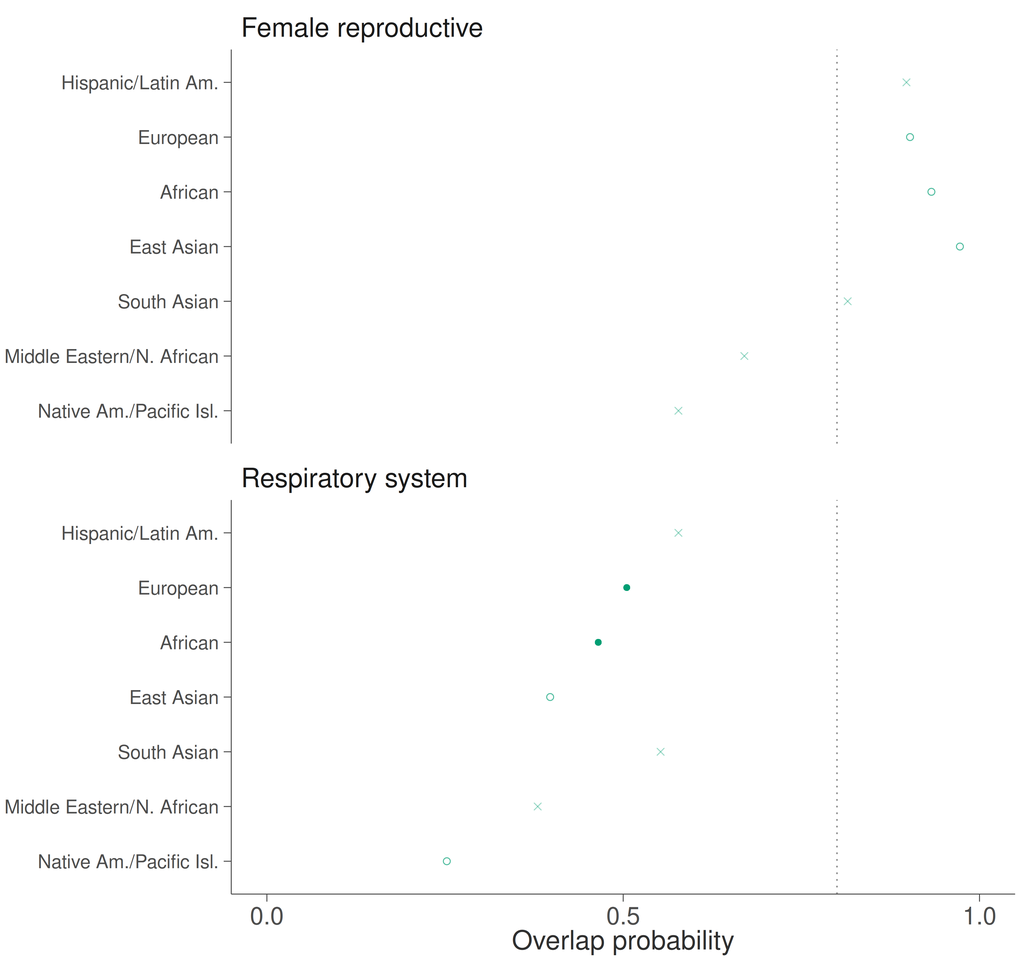

Endothelial overlap probability across unordered ethnicity groups for female reproductive and respiratory tissues. No lines connect categories.

```r
panel_h_respiratory <- plot_story_ethnicity("respiratory system")
panel_h_respiratory
```

- **Message/source:** ethnicity estimates are heterogeneous in uncertainty and support; respiratory includes supported African and European strata.
- **Size/change:** 58 × 55 mm; a horizontal dot plot replaces the ethnicity heatmap and avoids implying ordinal structure.
- **Weakness:** sparse categories, especially in female reproductive tissue, prevent strong demographic interpretation.
- **Recommendation:** preferred Panel H draft if Row 3 remains in the main figure; caption as exploratory marginal structure.

#### Draft H2 — female reproductive + skin

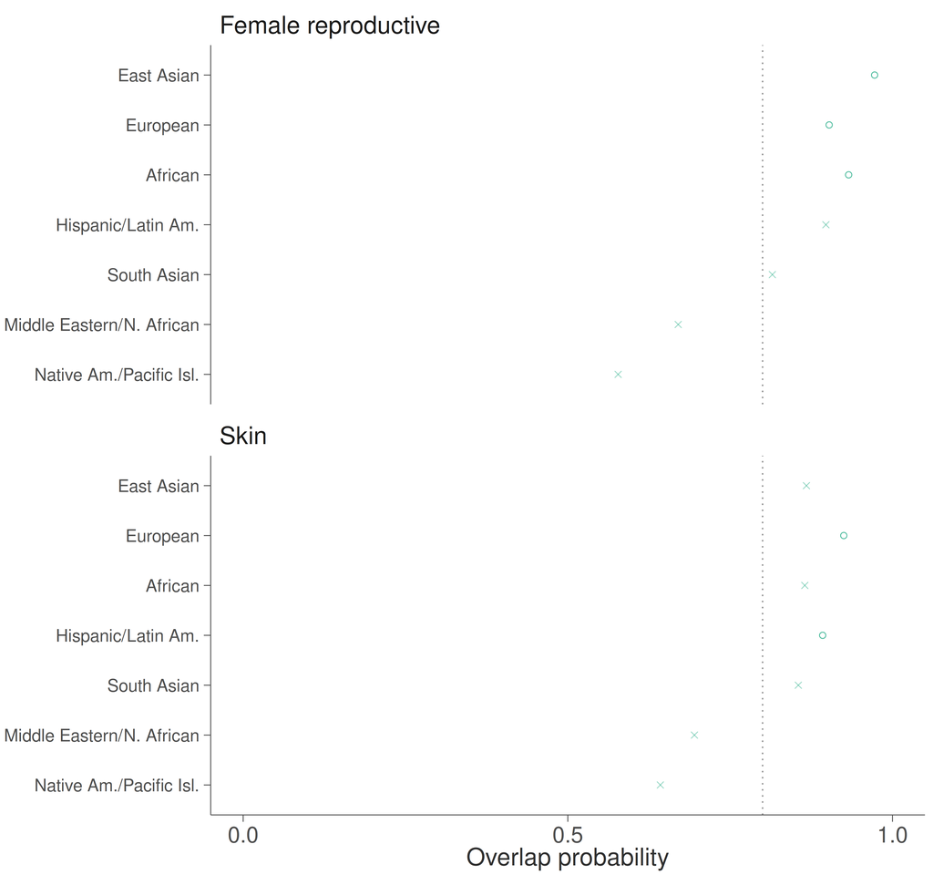

Endothelial overlap probability across unordered ethnicity groups for female reproductive and skin tissues. Skin strata are almost entirely extrapolated.

```r
panel_h_skin <- plot_story_ethnicity("integumentary system (skin)")
panel_h_skin
```

- **Message/source:** skin ethnicity estimates remain visible but their extrapolation-heavy basis is unmistakable.
- **Size/change:** 58 × 55 mm; restrained opacity and open/cross marks keep support secondary to the biological metric.
- **Weakness:** no skin ethnicity category has adequate direct donor support.
- **Recommendation:** do not use for the main-text story.

**Intended Row 3 message:** demographic marginals can refine a supported lead and a motivated negative comparator without turning sparse predictions into demographic claims. Female reproductive + respiratory is the cleaner main-text story; female reproductive + skin is extrapolation-sensitive and belongs in Supplementary development material.

# Recommended Fig. 3 direction

1. **Panels A–C:** use A1 (released source distribution with patient overlays), B (tumour bootstrap → HV anchor → epithelial Normal interval), and C (ranked paired-normal broad compartments). Keep A2 as an audit alternative.
2. **Row allocation:** retain the proposed 48 / 92 / 55 mm row heights with approximately 4 mm gutters; Row 2 remains the dominant visual row.
3. **Panels D–E:** use the prioritised two-column density-facet drafts. For D retain female reproductive, breast, liver, renal, respiratory, and initially skin for transparent story evaluation; move the other endothelial tissues to Supplementary. For E retain the seven supported tissues shown in E2 and move the full landscape to Supplementary.
4. **Panels F–H:** use female reproductive + respiratory. Respiratory is a motivated, adequately supported negative comparator; skin should not carry the main-text narrative while its tissue result is 98.6% extrapolation-weighted.
5. **Retire from the main figure:** the large TM4SF1 volcano, pooled broad-population bars, all-tissue forest plot, sex-wide forest plot, and age/ethnicity heatmaps. They remain useful audit or Supplementary outputs.
6. **Still requiring refinement:** replace the quantile-matched Row 2 Normal envelopes with exact tissue posterior draws if a lightweight draw cache is exported; decide whether skin remains in D after Row 3 is fixed; test final caption density and strip abbreviation after assembly.
7. **Estimated assembled size:** 183 mm × approximately 203 mm, within the 183 mm × 220 mm Nature-style cap, before caption.

## Figure-development self-review

- **Contribution — pass:** the row sequence carries one coherent story from target selection to tissue screening to demographic refinement.
- **Clarity — pass with one caption requirement:** model-specific scales and the plotting-only Row 2 density interpolation must be stated explicitly.
- **Experimental strength — needs model refit:** the released and reconstructed study evidence is transparent, but neither posteriorHCA fit is model-ready.
- **Evaluation completeness — needs one export:** exact tissue-level posterior draw matrices are absent from the cache; exporting them would remove the only visual approximation.
- **Design soundness — pass for development:** overlap, support, extrapolation, candidate status, and readiness remain separate; no panel implies toxicity or demographic causality.

## Claim–evidence check

| Draft claim | Evidence used | Status |
| --- | --- | --- |
| TM4SF1 is HV-enriched in the released tumour study | Released Figure 5A rank/effect and Figure 5B expression values | Supported |
| Endothelial and epithelial compartments warrant focused Normal screening | Patient broad-population summaries plus the two available posteriorHCA model classes | Supported with scope stated |
| Female reproductive is a lead endothelial overlap signal | Corrected tissue summary: P = 0.87, 10 donor keys; model readiness false | Supported as an ungated prioritisation signal only |
| Skin shows robust demographic structure | Two donor keys at tissue level and extrapolation-heavy strata | Not supported; excluded from recommended main-text story |